# pollution_time_series

Yuwei Hu

4/30/2022

## Visualization

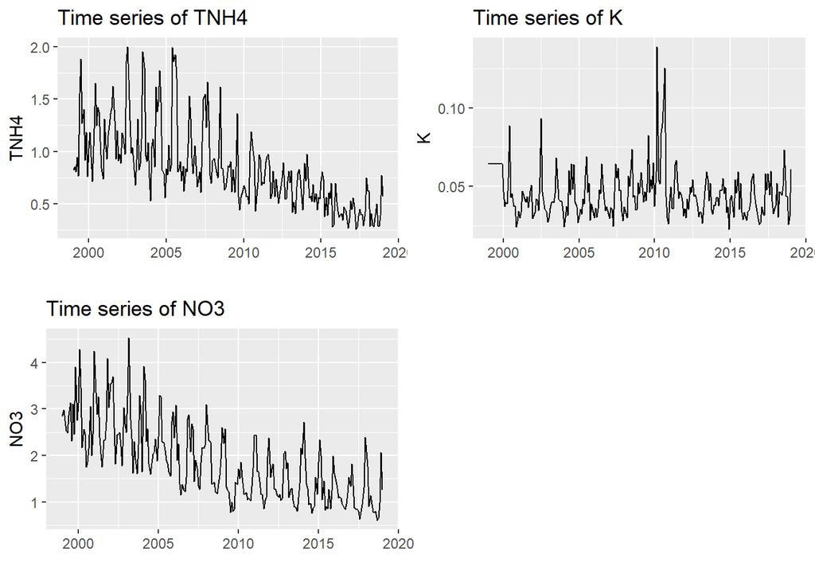

## Stationarity

From the time series graphs, we observed that time series of K is stationary, but time series of TNH4 and NO3 are not, which appear decreasing trend. Thus, we decompose time series of TNH4 and NO3 to separate them into trend and other components.

**Decomposition of TNH4 data**

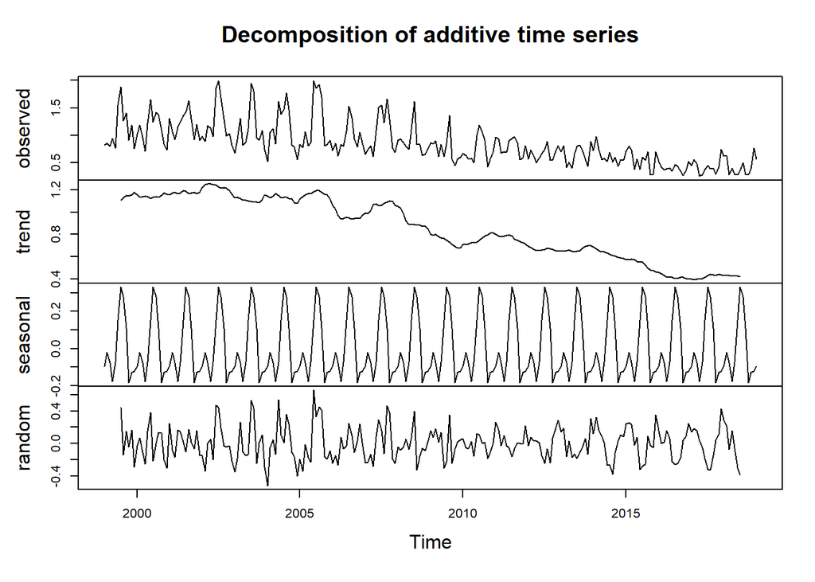

**Decomposition of NO3 data**

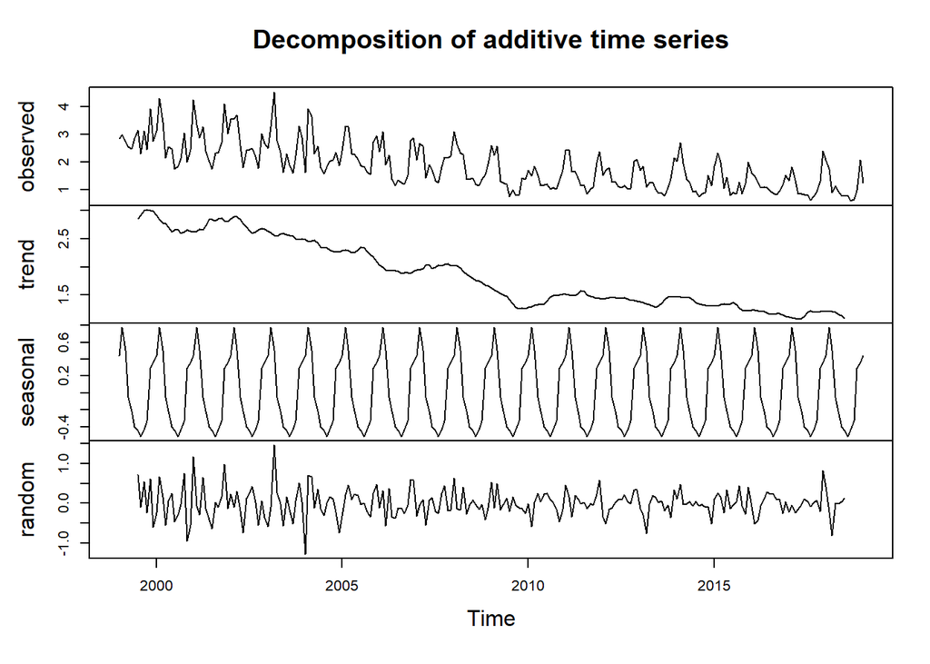

We observed that the trend in decomposition of these two time series is decreasing, same as what we supposed above.

## Differencing

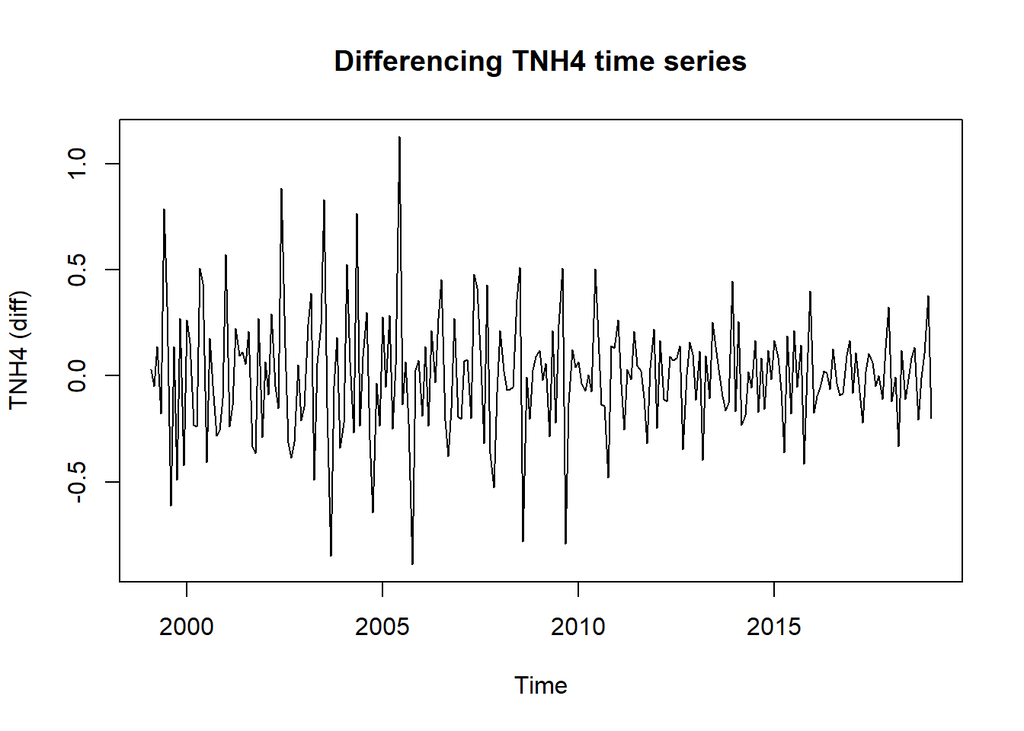

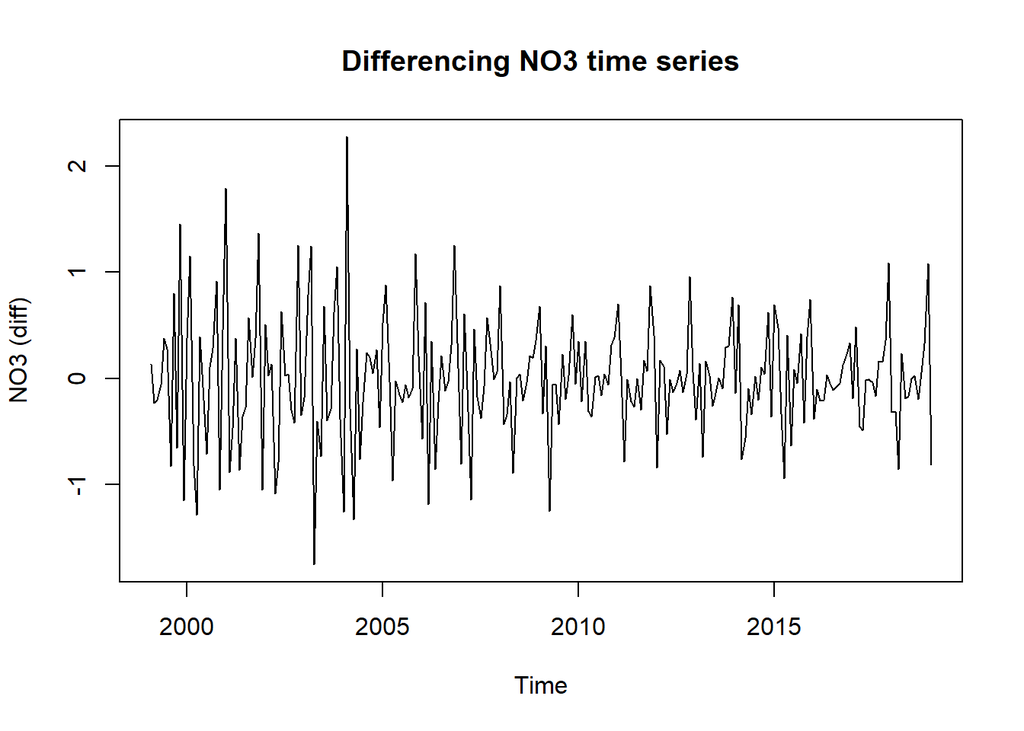

## ACF and PACF

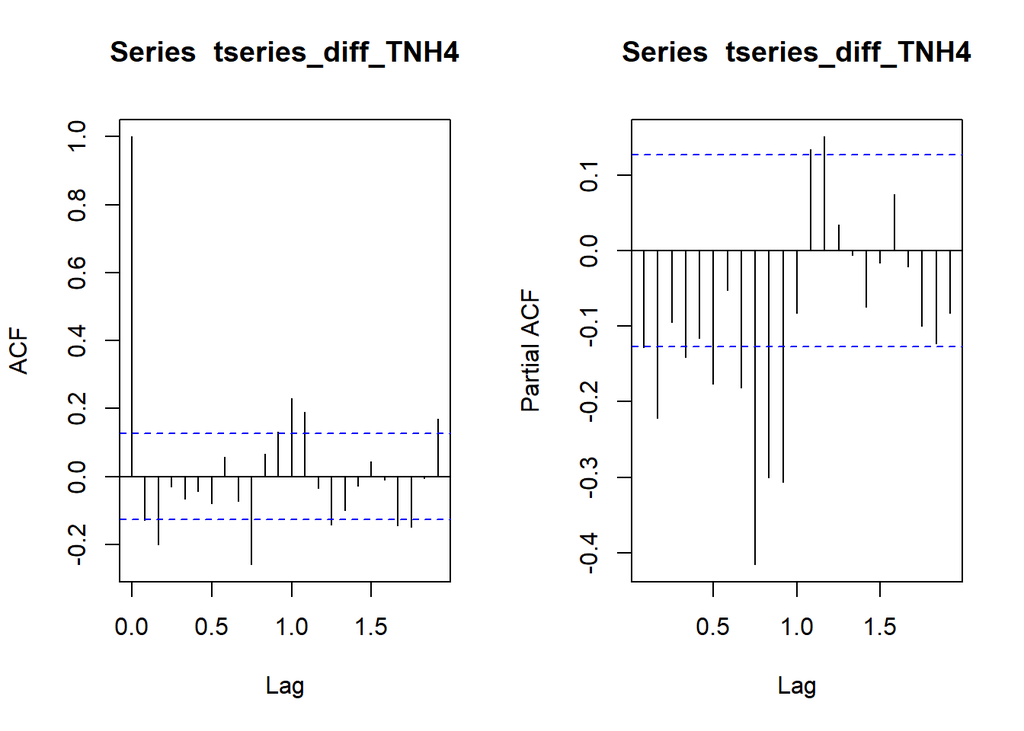

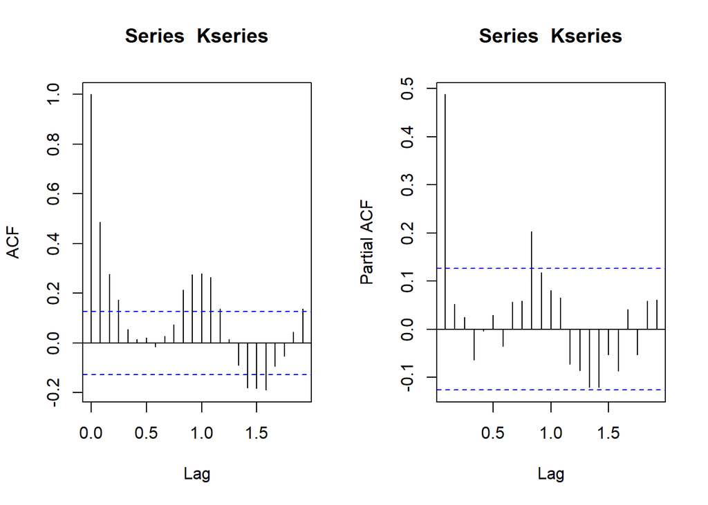

In ACF and PACF chart of K time series, we observe that ACF cuts off at 4th point and PACF cuts off at 1st point.

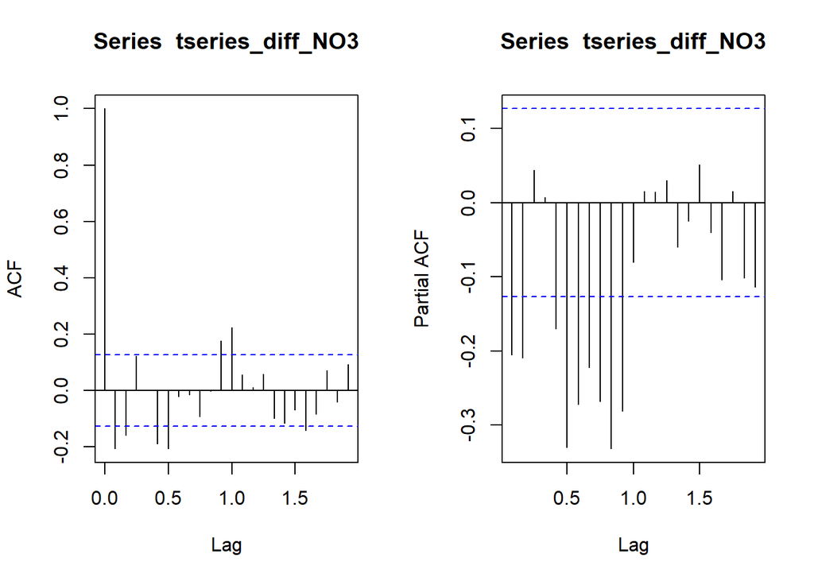

## Fitting in ARIMA model

```
##
## Call:
## arima(x = TNH4series, order = c(1, 1, 2))
##
## Coefficients:
##          ar1      ma1      ma2
##       0.3090  -0.6689  -0.2622
## s.e.  0.1219   0.1235   0.1126
##
## sigma^2 estimated as 0.06102:  log likelihood = -5.69,  aic = 19.38
```

We fit a ARIMA model for TNH4 time series including ARIMA(1,1,2) and ARIMA(1,1,3). ARIMA(1,1,2) has a smaller AIC value.

```
##
## Call:
## arima(x = Kseries, order = c(4, 1, 2))
##
## Coefficients:
##          ar1      ar2     ar3      ar4      ma1     ma2
##       1.1731  -0.3874  0.0165  -0.2284  -1.7119  0.8489
## s.e.  0.0816   0.1057  0.0997   0.0768   0.0499  0.0725
##
## sigma^2 estimated as 0.0001799:  log likelihood = 693.35,  aic = -1372.7
```

We fit a ARIMA model for K time series including ARIMA(4,1,1) and ARIMA(4,1,2). ARIMA(4,1,2) has a smaller AIC value.

```
##
## Call:
## arima(x = NO3series, order = c(2, 1, 4))
##
## Coefficients:
##          ar1      ar2      ma1     ma2     ma3      ma4
##       0.5768  -0.4172  -1.0221  0.4633  0.0162  -0.3645
## s.e.  0.2130   0.1690   0.1921  0.1755  0.1216   0.1026
##
## sigma^2 estimated as 0.2411:  log likelihood = -170.65,  aic = 355.29
```

We fit a ARIMA model for NO3 time series including ARIMA(2,1,3) and ARIMA(2,1,4). ARIMA(2,1,4) has a smaller AIC value.

## Forecasting by ARIMA

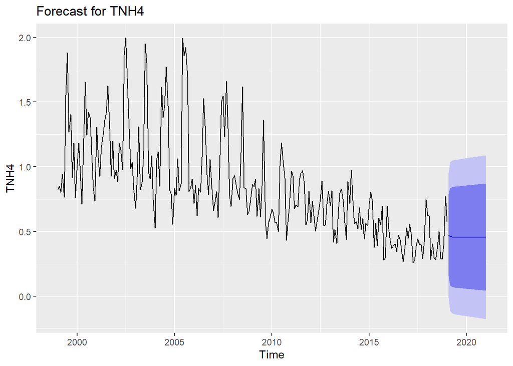

```
##          Point Forecast       Lo 95     Hi 95
## Feb 2019      0.4704895 -0.01368471 0.9546637
## Mar 2019      0.4605109 -0.11435625 1.0353780
## Apr 2019      0.4574277 -0.13176634 1.0466218
## May 2019      0.4564751 -0.13725927 1.0502095
## Jun 2019      0.4561808 -0.14019134 1.0525529
## Jul 2019      0.4560898 -0.14243317 1.0546128
## Aug 2019      0.4560617 -0.14446765 1.0565911
## Sep 2019      0.4560531 -0.14643481 1.0585409
## Oct 2019      0.4560504 -0.14837701 1.0604778
## Nov 2019      0.4560495 -0.15030728 1.0624064
## Dec 2019      0.4560493 -0.15222967 1.0643282
## Jan 2020      0.4560492 -0.15414545 1.0662439
## Feb 2020      0.4560492 -0.15605507 1.0681534
## Mar 2020      0.4560492 -0.15795870 1.0700570
## Apr 2020      0.4560492 -0.15985643 1.0719548
## May 2020      0.4560492 -0.16174833 1.0738467
## Jun 2020      0.4560492 -0.16363445 1.0757328
## Jul 2020      0.4560492 -0.16551484 1.0776132
## Aug 2020      0.4560492 -0.16738957 1.0794879
## Sep 2020      0.4560492 -0.16925867 1.0813570
## Oct 2020      0.4560492 -0.17112220 1.0832205
## Nov 2020      0.4560492 -0.17298022 1.0850786
## Dec 2020      0.4560492 -0.17483276 1.0869311
## Jan 2021      0.4560492 -0.17667987 1.0887782
```

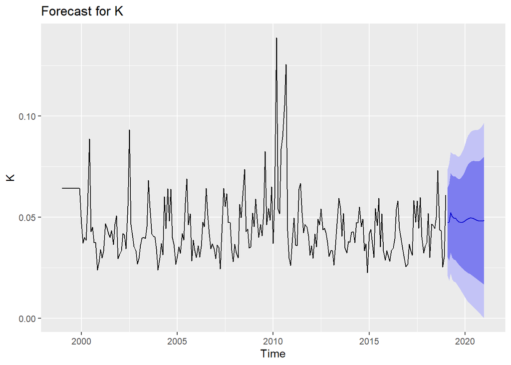

```
##          Point Forecast        Lo 95      Hi 95
## Feb 2019     0.04744372 0.0211534448 0.07373400
## Mar 2019     0.04753338 0.0185809711 0.07648579
## Apr 2019     0.05218984 0.0222452596 0.08213441
## May 2019     0.05046001 0.0193851696 0.08153484
## Jun 2019     0.04969012 0.0182798062 0.08110044
## Jul 2019     0.04951319 0.0179490724 0.08107732
## Aug 2019     0.04851193 0.0167114440 0.08031242
## Sep 2019     0.04778823 0.0155790097 0.07999745
## Oct 2019     0.04750000 0.0145156348 0.08048437
## Nov 2019     0.04746613 0.0131922661 0.08174000
## Dec 2019     0.04775482 0.0117670400 0.08374259
## Jan 2020     0.04826714 0.0103889659 0.08614531
## Feb 2020     0.04882161 0.0091647947 0.08847843
## Mar 2020     0.04928611 0.0081705838 0.09040165
## Apr 2020     0.04955876 0.0073655886 0.09175194
## May 2020     0.04959080 0.0066445826 0.09253703
## Jun 2020     0.04940379 0.0059191798 0.09288840
## Jul 2020     0.04907038 0.0051488812 0.09299189
## Aug 2020     0.04868995 0.0043362697 0.09304364
## Sep 2020     0.04836241 0.0034998993 0.09322492
## Oct 2020     0.04816274 0.0026514752 0.09367401
## Nov 2020     0.04812527 0.0017964740 0.09445406
## Dec 2020     0.04824014 0.0009471354 0.09553315
## Jan 2021     0.04846094 0.0001266716 0.09679521
```

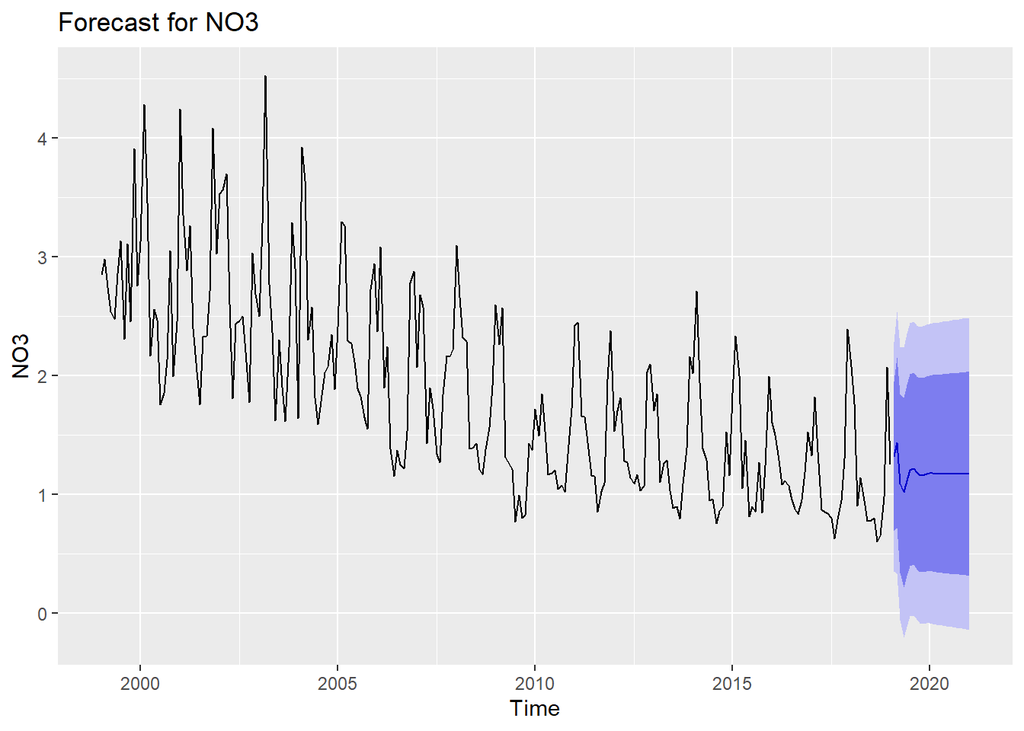

```
##          Point Forecast       Lo 95    Hi 95
## Feb 2019       1.320809  0.35833550 2.283282
## Mar 2019       1.436820  0.33621064 2.537430
## Apr 2019       1.094883 -0.05441291 2.244179
## May 2019       1.020643 -0.19906240 2.240348
## Jun 2019       1.120474 -0.11346486 2.354412
## Jul 2019       1.209024 -0.02520528 2.443254
## Aug 2019       1.218450 -0.01607280 2.452972
## Sep 2019       1.186944 -0.05113071 2.425019
## Oct 2019       1.164841 -0.08027554 2.409957
## Nov 2019       1.165236 -0.08629621 2.416768
## Dec 2019       1.174685 -0.08143211 2.430802
## Jan 2020       1.179970 -0.07999836 2.439938
## Feb 2020       1.179076 -0.08496871 2.443121
## Mar 2020       1.176356 -0.09219550 2.444907
## Apr 2020       1.175160 -0.09803968 2.448359
## May 2020       1.175605 -0.10212623 2.453336
## Jun 2020       1.176360 -0.10576488 2.458486
## Jul 2020       1.176611 -0.10986531 2.463086
## Aug 2020       1.176440 -0.11440555 2.467285
## Sep 2020       1.176237 -0.11899424 2.471468
## Oct 2020       1.176191 -0.12341497 2.475797
## Nov 2020       1.176249 -0.12770638 2.480205
## Dec 2020       1.176302 -0.13198113 2.484585
## Jan 2021       1.176308 -0.13628817 2.488904
```